# Behavioral analyses

Raphael Q. Gastrock

2025-05-08

This document contains figures and statistics used in analyzing the behavioral data across the different perturbation types.

```r
source('ana/shared.R')
source('ana/learningRates.R')
source('ana/movementAnalyses.R')
source('ana/reachAftereffects.R')
source('ana/orderEffects.R')
```

# Measures analyzing reach performance

We investigate how learning progresses for the different perturbation types, and look into other movement measures such as reaction time, movement time, and path length.

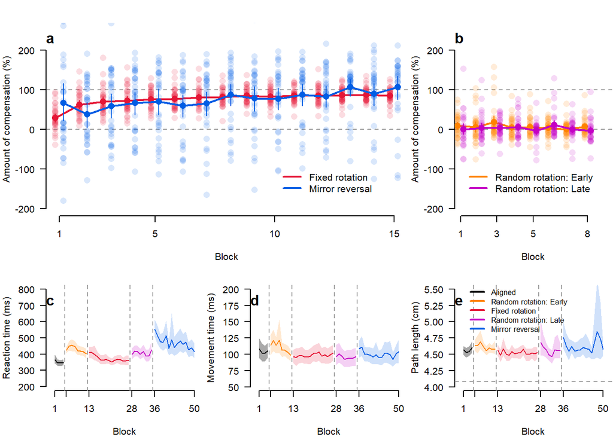

```r
plotBehaviorLearning()
```

We find that participants learned the fixed rotation and mirror perturbations. However, variability across participants is greater in the mirror perturbation. As expected, we do not observe learning in the random perturbation.

We also confirm expected pattern of results for RT, MT and PL. We find that RTs are initially slower across all perturbation types, but the mirror perturbation produced the slowest RTs early on in training. From the plots, we also do not observe differences in MTs and PLs, but PL in the mirror condition seems to have higher variability.

These findings are similar to our findings in a previous study (Gastrock et al., 2024). In the current study, we perform statistical tests for the behavioral data to confirm learning in the fixed rotation and mirror perturbations. The rest of the analyses focuses on the EEG data.

From these behavioral data, we decided on our early vs. late and small vs. large conditions.

# Statistics

```r
getLCBlockedtTests()
```

```
## Rotation (first block) compared to Mirror (first block):
##
##  Paired t-test
##
## data:  ROTdat$reachdev and MIRdat$reachdev
## t = -1.5115, df = 31, p-value = 0.1408
## alternative hypothesis: true mean difference is not equal to 0
## 95 percent confidence interval:
##  -88.24315  13.12059
## sample estimates:
## mean difference
##       -37.56128
##
## Effect Size - Cohen d:
## [1] 0.2672018
## Bayesian t-test Rotation (first block) compared to Mirror (first block):
## Bayes factor analysis
## --------------
## [1] Alt., r=0.707 : 0.5277788 ±0.03%
##
## Against denominator:
##   Null, mu = 0
## ---
## Bayes factor type: BFoneSample, JZS
##
## Rotation (second block) compared to Mirror (second block):
##
##  Paired t-test
##
## data:  ROTdat$reachdev and MIRdat$reachdev
## t = 1.5345, df = 31, p-value = 0.135
## alternative hypothesis: true mean difference is not equal to 0
## 95 percent confidence interval:
##  -8.209784 58.105232
## sample estimates:
## mean difference
##        24.94772
##
## Effect Size - Cohen d:
## [1] 0.2712693
```

[output cut: 94 more lines]

```
## sample estimates:
## mean difference
##       -69.53964
##
## Effect Size - Cohen d:
## [1] 0.5736455
## Bayesian t-test Mirror (second block) compared to Mirror (last block):
## Bayes factor analysis
## --------------
## [1] Alt., r=0.707 : 13.11968 ±0%
##
## Against denominator:
##   Null, mu = 0
## ---
## Bayes factor type: BFoneSample, JZS
```

We compare the first, second, and last blocks (6 trials each) of training in the fixed rotation and mirror perturbations, and find no differences between the two. However, we do confirm that learning has occurred in the rotation perturbation when comparing the first and last block of training, where the amount of compensation is higher at the end of training. We do not find a difference between the first and last block of mirror training, but this is likely due to the high variability in block 1. However, when we compare the second and last blocks of mirror training, we find a difference, thereby confirming that learning has occurred by the end of training.

# Statistics: Random Rotation trials

```r
getRDMBlockedtTests()
```

```
## Random Early (first block) compared to Random Late (first block):
##
##  Paired t-test
##
## data:  RDM0dat$reachdev and RDM1dat$reachdev
## t = 1.0519, df = 31, p-value = 0.301
## alternative hypothesis: true mean difference is not equal to 0
## 95 percent confidence interval:
##  -8.406177 26.312687
## sample estimates:
## mean difference
##        8.953255
##
## Effect Size - Cohen d:
## [1] 0.1859504
## Bayesian t-test Random Early (first block) compared to Random Late (first block):
## Bayes factor analysis
## --------------
## [1] Alt., r=0.707 : 0.3133921 ±0.03%
##
## Against denominator:
##   Null, mu = 0
## ---
## Bayes factor type: BFoneSample, JZS
##
## Random Early (second block) compared to Random Late (second block):
##
##  Paired t-test
##
## data:  RDM0dat$reachdev and RDM1dat$reachdev
## t = 0.35835, df = 31, p-value = 0.7225
## alternative hypothesis: true mean difference is not equal to 0
## 95 percent confidence interval:
##  -14.34229  20.45651
## sample estimates:
## mean difference
##        3.057111
##
## Effect Size - Cohen d:
## [1] 0.06334736
```

[output cut: 94 more lines]

```
## sample estimates:
## mean difference
##        12.67311
##
## Effect Size - Cohen d:
## [1] 0.3821992
## Bayesian t-test Random Early (first block) compared to Random Late (last block):
## Bayes factor analysis
## --------------
## [1] Alt., r=0.707 : 1.44095 ±0.02%
##
## Against denominator:
##   Null, mu = 0
## ---
## Bayes factor type: BFoneSample, JZS
```

We confirm that participants do not learn to compensate for the random rotation.

# Washout trials: Reach aftereffects

We also plot data from washout trials, to confirm expectations that reach aftereffects, or the persistent deviation in hand movements despite perturbation removal, are only observed for the fixed rotation and not the mirror reversal perturbation.

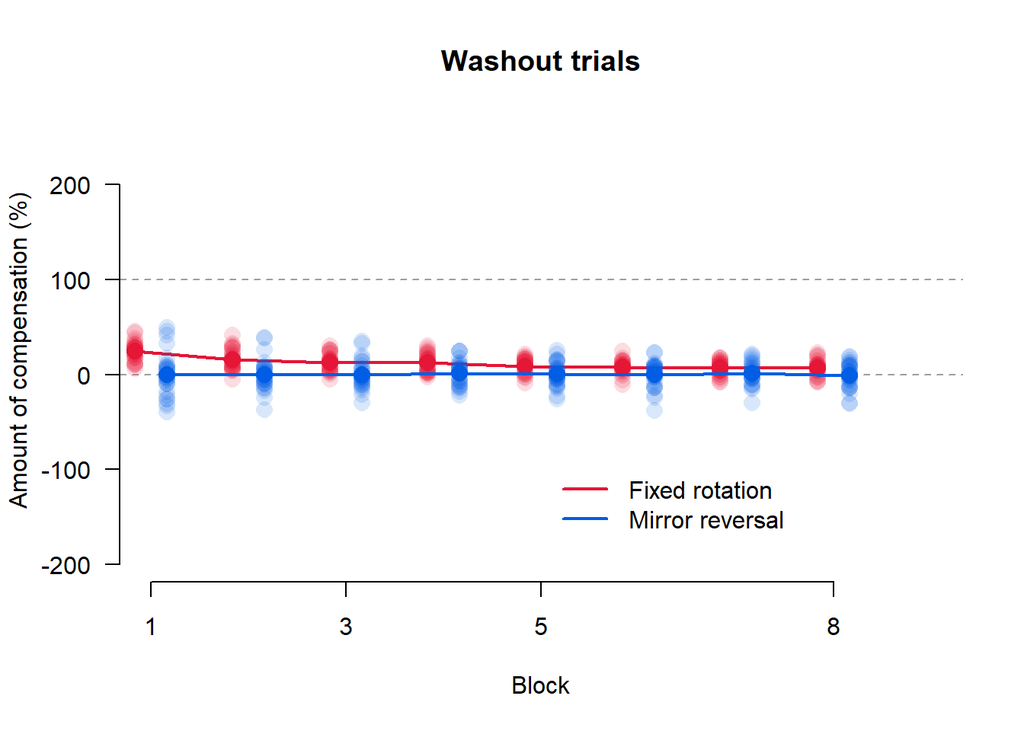

```r
plotCollapsedBlockedIndRAE()
```

We find a more gradual decrease in compensation for the fixed rotation compared to the mirror reversal, thereby confirming our expectations that aftereffects are only observed in the fixed rotation perturbation.

# Statistics

```r
getRAEBlockedtTests()
```

```
## Rotation (first block) compared to Mirror (first block):
##
##  Paired t-test
##
## data:  ROTdat$reachdev and MIRdat$reachdev
## t = 6.3686, df = 31, p-value = 4.318e-07
## alternative hypothesis: true mean difference is not equal to 0
## 95 percent confidence interval:
##  16.77543 32.58184
## sample estimates:
## mean difference
##        24.67863
##
## Effect Size - Cohen d:
## [1] 1.125822
## Bayesian t-test Rotation (first block) compared to Mirror (first block):
## Bayes factor analysis
## --------------
## [1] Alt., r=0.707 : 38248.19 ±0%
##
## Against denominator:
##   Null, mu = 0
## ---
## Bayes factor type: BFoneSample, JZS
##
## Rotation (second block) compared to Mirror (second block):
##
##  Paired t-test
##
## data:  ROTdat$reachdev and MIRdat$reachdev
## t = 4.9926, df = 31, p-value = 2.194e-05
## alternative hypothesis: true mean difference is not equal to 0
## 95 percent confidence interval:
##   9.63945 22.95441
## sample estimates:
## mean difference
##        16.29693
##
## Effect Size - Cohen d:
## [1] 0.8825667
```

[output cut: 69 more lines]

```
## sample estimates:
## mean difference
##       0.9218983
##
## Effect Size - Cohen d:
## [1] 0.03920282
## Bayesian t-test Mirror (first block) compared to Mirror (last block):
## Bayes factor analysis
## --------------
## [1] Alt., r=0.707 : 0.193193 ±0.04%
##
## Against denominator:
##   Null, mu = 0
## ---
## Bayes factor type: BFoneSample, JZS
```

We find that the compensation for the fixed rotation is different from compensation in the mirror perturbation for the first, second, and last blocks of washout, suggesting that compensation in the fixed rotation is higher compared to the mirror perturbation. Moreover, we confirm that aftereffects are present in the fixed rotation, given the significant difference between the first and last blocks of rotation training. We do not find the same difference in the mirror perturbation, suggesting an absence of aftereffects for this perturbation type.

However, it is interesting to note that the compensation for the fixed rotation remains higher than compensation in the mirror perturbation until the last block of washout.

# Perturbation order effects

We check for any differences in performance, depending on whether participants trained with one perturbation first or after training in the other perturbation. We compare performance both during training and during washout trials.

## Rotation Perturbation training

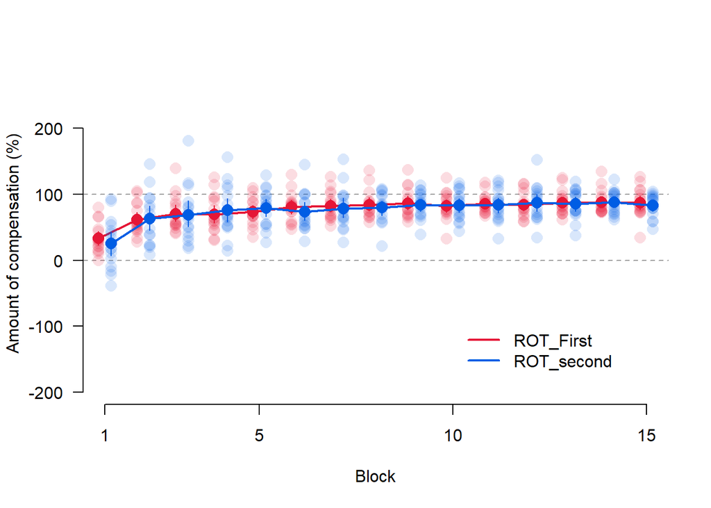

```r
plotROTBlocked()
```

```r
getROTBlockedtTests()
```

```
## Rotation first compared to Rotation second (first block):
##
##  Welch Two Sample t-test
##
## data:  ROTdat1$reachdev and ROTdat2$reachdev
## t = 0.74242, df = 24.279, p-value = 0.465
## alternative hypothesis: true difference in means is not equal to 0
## 95 percent confidence interval:
##  -14.41385  30.62490
## sample estimates:
## mean of x mean of y
##  33.06922  24.96369
##
## Effect Size - Cohen d:
## [1] 0.262485
## Bayesian t-test Rotation first compared to Rotation second (first block):
## Bayes factor analysis
## --------------
## [1] Alt., r=0.707 : 0.4153533 ±0%
##
## Against denominator:
##   Null, mu1-mu2 = 0
## ---
## Bayes factor type: BFindepSample, JZS
##
## Rotation first compared to Rotation second (second block):
##
##  Welch Two Sample t-test
##
## data:  ROTdat1$reachdev and ROTdat2$reachdev
## t = -0.1338, df = 24.601, p-value = 0.8946
## alternative hypothesis: true difference in means is not equal to 0
## 95 percent confidence interval:
##  -24.51470  21.52606
## sample estimates:
## mean of x mean of y
##  61.47173  62.96604
##
## Effect Size - Cohen d:
## [1] 0.04730564
```

[output cut: 19 more lines]

```
## sample estimates:
## mean of x mean of y
##  86.86420  82.64159
##
## Effect Size - Cohen d:
## [1] 0.2157772
## Bayesian t-test Rotation first compared to Rotation second (last block):
## Bayes factor analysis
## --------------
## [1] Alt., r=0.707 : 0.3879348 ±0%
##
## Against denominator:
##   Null, mu1-mu2 = 0
## ---
## Bayes factor type: BFindepSample, JZS
```

We find no order effects, suggesting that learning in one perturbation does not affect learning in the other perturbation type.

## Rotation Washout trials

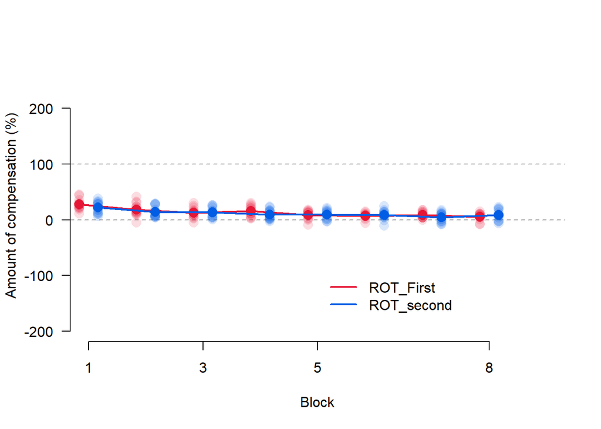

```r
plotROTRAEBlocked()
```

```r
getROTRAEBlockedtTests()
```

```
## Rotation first compared to Rotation second (first block):
##
##  Welch Two Sample t-test
##
## data:  ROTdat1$reachdev and ROTdat2$reachdev
## t = 1.6735, df = 29.569, p-value = 0.1048
## alternative hypothesis: true difference in means is not equal to 0
## 95 percent confidence interval:
##  -1.216161 12.217411
## sample estimates:
## mean of x mean of y
##  27.27978  21.77916
##
## Effect Size - Cohen d:
## [1] 0.5916771
## Bayesian t-test Rotation first compared to Rotation second (first block):
## Bayes factor analysis
## --------------
## [1] Alt., r=0.707 : 0.9615892 ±0%
##
## Against denominator:
##   Null, mu1-mu2 = 0
## ---
## Bayes factor type: BFindepSample, JZS
##
## Rotation first compared to Rotation second (second block):
##
##  Welch Two Sample t-test
##
## data:  ROTdat1$reachdev and ROTdat2$reachdev
## t = 1.1647, df = 29.397, p-value = 0.2535
## alternative hypothesis: true difference in means is not equal to 0
## 95 percent confidence interval:
##  -3.188079 11.634091
## sample estimates:
## mean of x mean of y
##  18.11251  13.88951
##
## Effect Size - Cohen d:
## [1] 0.4117961
```

[output cut: 19 more lines]

```
## sample estimates:
## mean of x mean of y
##  5.495637  8.171968
##
## Effect Size - Cohen d:
## [1] 0.3419486
## Bayesian t-test Rotation first compared to Rotation second (last block):
## Bayes factor analysis
## --------------
## [1] Alt., r=0.707 : 0.4806566 ±0%
##
## Against denominator:
##   Null, mu1-mu2 = 0
## ---
## Bayes factor type: BFindepSample, JZS
```

We find no order effects, suggesting that compensation during washout does not differ, regardless of whether participants experienced the rotation perturbation first or after the other perturbation.

## Mirror Perturbation training

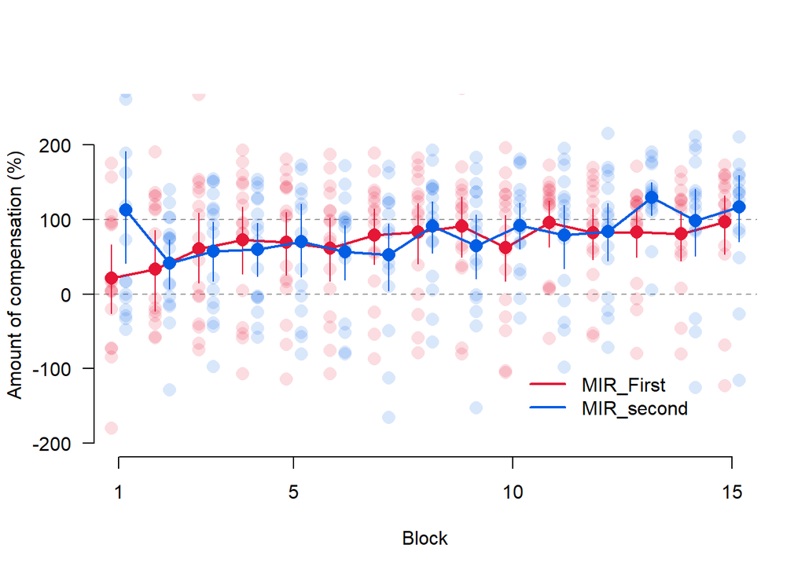

```r
plotMIRBlocked()
```

```r
getMIRBlockedtTests()
```

```
## Mirror first compared to Mirror second (first block):
##
##  Welch Two Sample t-test
##
## data:  MIRdat1$reachdev and MIRdat2$reachdev
## t = -1.9774, df = 24.712, p-value = 0.05925
## alternative hypothesis: true difference in means is not equal to 0
## 95 percent confidence interval:
##  -186.307822    3.844852
## sample estimates:
## mean of x mean of y
##  20.96199 112.19348
##
## Effect Size - Cohen d:
## [1] 0.6991237
## Bayesian t-test Mirror first compared to Mirror second (first block):
## Bayes factor analysis
## --------------
## [1] Alt., r=0.707 : 1.435579 ±0.01%
##
## Against denominator:
##   Null, mu1-mu2 = 0
## ---
## Bayes factor type: BFindepSample, JZS
##
## Mirror first compared to Mirror second (second block):
##
##  Welch Two Sample t-test
##
## data:  MIRdat1$reachdev and MIRdat2$reachdev
## t = -0.22942, df = 25.194, p-value = 0.8204
## alternative hypothesis: true difference in means is not equal to 0
## 95 percent confidence interval:
##  -75.85589  60.64486
## sample estimates:
## mean of x mean of y
##  33.46840  41.07392
##
## Effect Size - Cohen d:
## [1] 0.08111091
```

[output cut: 19 more lines]

```
## sample estimates:
## mean of x mean of y
##  96.89677 116.72483
##
## Effect Size - Cohen d:
## [1] 0.2264777
## Bayesian t-test Mirror first compared to Mirror second (last block):
## Bayes factor analysis
## --------------
## [1] Alt., r=0.707 : 0.3935959 ±0%
##
## Against denominator:
##   Null, mu1-mu2 = 0
## ---
## Bayes factor type: BFindepSample, JZS
```

We find no order effects, suggesting that learning in one perturbation does not affect learning in the other perturbation type.

## Mirror Washout trials

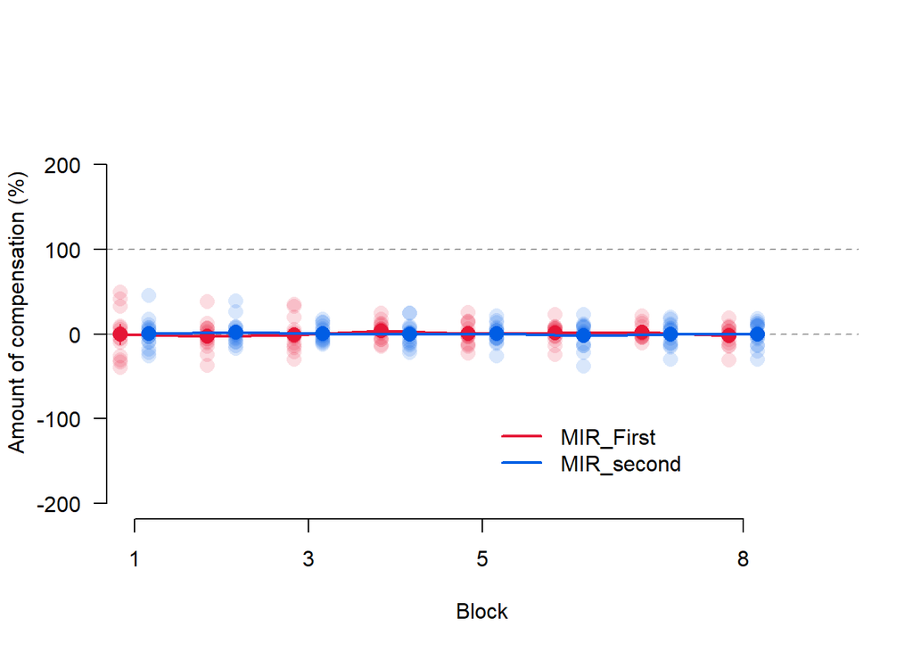

```r
plotMIRRAEBlocked()
```

```r
getMIRRAEBlockedtTests()
```

```
## Mirror first compared to Mirror second (first block):
##
##  Welch Two Sample t-test
##
## data:  MIRdat1$reachdev and MIRdat2$reachdev
## t = -0.059301, df = 25.98, p-value = 0.9532
## alternative hypothesis: true difference in means is not equal to 0
## 95 percent confidence interval:
##  -16.22175  15.31204
## sample estimates:
##   mean of x   mean of y
## -0.37659113  0.07826056
##
## Effect Size - Cohen d:
## [1] 0.02096615
## Bayesian t-test Mirror first compared to Mirror second (first block):
## Bayes factor analysis
## --------------
## [1] Alt., r=0.707 : 0.3366603 ±0%
##
## Against denominator:
##   Null, mu1-mu2 = 0
## ---
## Bayes factor type: BFindepSample, JZS
##
## Mirror first compared to Mirror second (second block):
##
##  Welch Two Sample t-test
##
## data:  MIRdat1$reachdev and MIRdat2$reachdev
## t = -0.78957, df = 29.394, p-value = 0.4361
## alternative hypothesis: true difference in means is not equal to 0
## 95 percent confidence interval:
##  -15.471253   6.849304
## sample estimates:
## mean of x mean of y
## -2.451408  1.859567
##
## Effect Size - Cohen d:
## [1] 0.2791544
```

[output cut: 19 more lines]

```
## sample estimates:
##  mean of x  mean of y
## -1.9581095 -0.1840175
##
## Effect Size - Cohen d:
## [1] 0.1385216
## Bayesian t-test Mirror first compared to Mirror second (last block):
## Bayes factor analysis
## --------------
## [1] Alt., r=0.707 : 0.3566762 ±0%
##
## Against denominator:
##   Null, mu1-mu2 = 0
## ---
## Bayes factor type: BFindepSample, JZS
```

We find no order effects, suggesting that participants had no aftereffects, regardless of when they experienced the mirror perturbation.

# Target location effects

We check for any differences in performance, depending on whether participants experienced target locations, either in the clockwise or counterclockwise direction, relative to the workspace axis. We compare performance both during training and during washout trials.

## Rotation Perturbation training

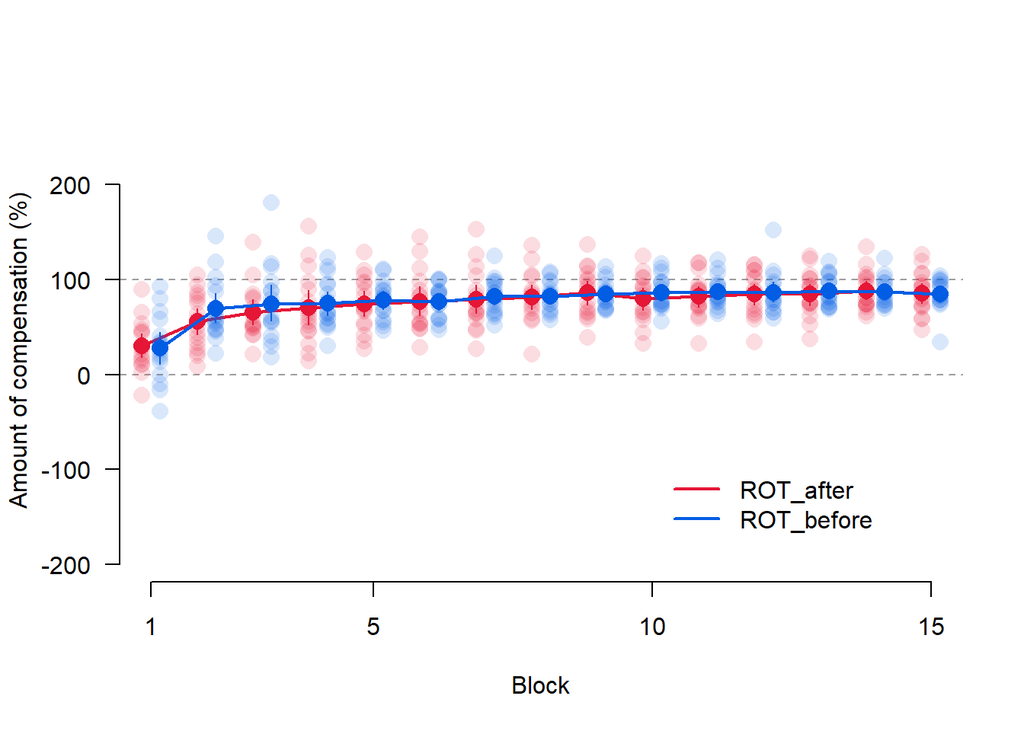

```r
plotROTTargetBlocked()
```

```r
getROTTargetBlockedtTests()
```

```
## Rotation before axis compared to after axis (first block):
##
##  Welch Two Sample t-test
##
## data:  ROTdat1$reachdev and ROTdat2$reachdev
## t = 0.2143, df = 28.059, p-value = 0.8319
## alternative hypothesis: true difference in means is not equal to 0
## 95 percent confidence interval:
##  -20.18974  24.90833
## sample estimates:
## mean of x mean of y
##  30.19610  27.83681
##
## Effect Size - Cohen d:
## [1] 0.07576787
## Bayesian t-test Rotation before axis compared to after axis (first block):
## Bayes factor analysis
## --------------
## [1] Alt., r=0.707 : 0.342209 ±0%
##
## Against denominator:
##   Null, mu1-mu2 = 0
## ---
## Bayes factor type: BFindepSample, JZS
##
## Rotation before axis compared to after axis (second block):
##
##  Welch Two Sample t-test
##
## data:  ROTdat1$reachdev and ROTdat2$reachdev
## t = -1.2253, df = 29.705, p-value = 0.2301
## alternative hypothesis: true difference in means is not equal to 0
## 95 percent confidence interval:
##  -35.633174   8.915454
## sample estimates:
## mean of x mean of y
##  55.53946  68.89831
##
## Effect Size - Cohen d:
## [1] 0.433226
```

[output cut: 19 more lines]

```
## sample estimates:
## mean of x mean of y
##  85.36777  84.13803
##
## Effect Size - Cohen d:
## [1] 0.06248634
## Bayesian t-test Rotation before axis compared to after axis (last block):
## Bayes factor analysis
## --------------
## [1] Alt., r=0.707 : 0.3402773 ±0%
##
## Against denominator:
##   Null, mu1-mu2 = 0
## ---
## Bayes factor type: BFindepSample, JZS
```

We find no target location effects, suggesting that rotation perturbation learning is not affected by the location of targets relative to the workspace axis.

## Rotation Washout trials

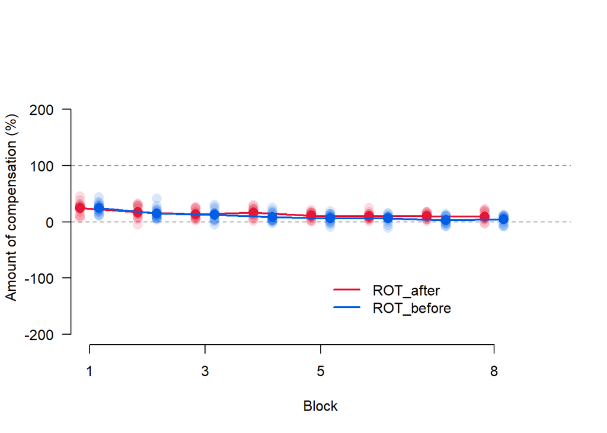

```r
plotROTRAETargetBlocked()
```

```r
getROTRAETargetBlockedtTests()
```

```
## Rotation before axis compared to after axis (first block):
##
##  Welch Two Sample t-test
##
## data:  ROTdat1$reachdev and ROTdat2$reachdev
## t = 0.12585, df = 29.785, p-value = 0.9007
## alternative hypothesis: true difference in means is not equal to 0
## 95 percent confidence interval:
##  -6.586872  7.451717
## sample estimates:
## mean of x mean of y
##  24.74568  24.31326
##
## Effect Size - Cohen d:
## [1] 0.04449541
## Bayesian t-test Rotation before axis compared to after axis (first block):
## Bayes factor analysis
## --------------
## [1] Alt., r=0.707 : 0.3382636 ±0%
##
## Against denominator:
##   Null, mu1-mu2 = 0
## ---
## Bayes factor type: BFindepSample, JZS
##
## Rotation before axis compared to after axis (second block):
##
##  Welch Two Sample t-test
##
## data:  ROTdat1$reachdev and ROTdat2$reachdev
## t = 0.64344, df = 29.95, p-value = 0.5248
## alternative hypothesis: true difference in means is not equal to 0
## 95 percent confidence interval:
##  -5.150307  9.887913
## sample estimates:
## mean of x mean of y
##  17.18541  14.81661
##
## Effect Size - Cohen d:
## [1] 0.2274898
```

[output cut: 19 more lines]

```
## sample estimates:
## mean of x mean of y
##  9.550402  4.117203
##
## Effect Size - Cohen d:
## [1] 0.7306526
## Bayesian t-test Rotation before axis compared to after axis (last block):
## Bayes factor analysis
## --------------
## [1] Alt., r=0.707 : 1.632291 ±0.01%
##
## Against denominator:
##   Null, mu1-mu2 = 0
## ---
## Bayes factor type: BFindepSample, JZS
```

We find no target location effects, suggesting that compensation during washout does not differ regardless of target locations.

## Mirror Perturbation training

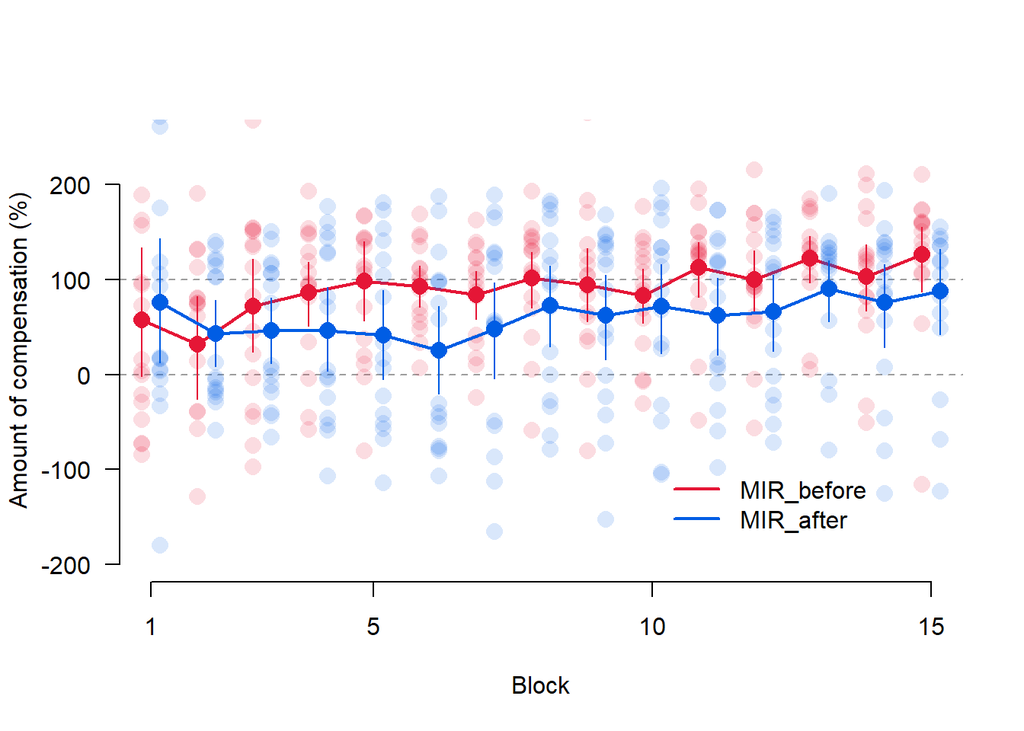

```r
plotMIRTargetBlocked()
```

```r
getMIRTargetBlockedtTests()
```

```
## Mirror before axis compared to after axis (first block):
##
##  Welch Two Sample t-test
##
## data:  MIRdat1$reachdev and MIRdat2$reachdev
## t = -0.36391, df = 29.992, p-value = 0.7185
## alternative hypothesis: true difference in means is not equal to 0
## 95 percent confidence interval:
##  -117.76766   82.14595
## sample estimates:
## mean of x mean of y
##  57.67231  75.48316
##
## Effect Size - Cohen d:
## [1] 0.1286607
## Bayesian t-test Mirror before axis compared to after axis (first block):
## Bayes factor analysis
## --------------
## [1] Alt., r=0.707 : 0.3537969 ±0%
##
## Against denominator:
##   Null, mu1-mu2 = 0
## ---
## Bayes factor type: BFindepSample, JZS
##
## Mirror before axis compared to after axis (second block):
##
##  Welch Two Sample t-test
##
## data:  MIRdat1$reachdev and MIRdat2$reachdev
## t = -0.31559, df = 25.789, p-value = 0.7549
## alternative hypothesis: true difference in means is not equal to 0
## 95 percent confidence interval:
##  -78.57203  57.66399
## sample estimates:
## mean of x mean of y
##  32.04415  42.49817
##
## Effect Size - Cohen d:
## [1] 0.1115765
```

[output cut: 19 more lines]

```
## sample estimates:
## mean of x mean of y
## 125.81616  87.80544
##
## Effect Size - Cohen d:
## [1] 0.4423288
## Bayesian t-test Mirror before axis compared to after axis (last block):
## Bayes factor analysis
## --------------
## [1] Alt., r=0.707 : 0.6091873 ±0%
##
## Against denominator:
##   Null, mu1-mu2 = 0
## ---
## Bayes factor type: BFindepSample, JZS
```

We find no target location effects, suggesting that mirror perturbation learning is not affected by the location of targets relative to the workspace axis.

## Mirror Washout trials

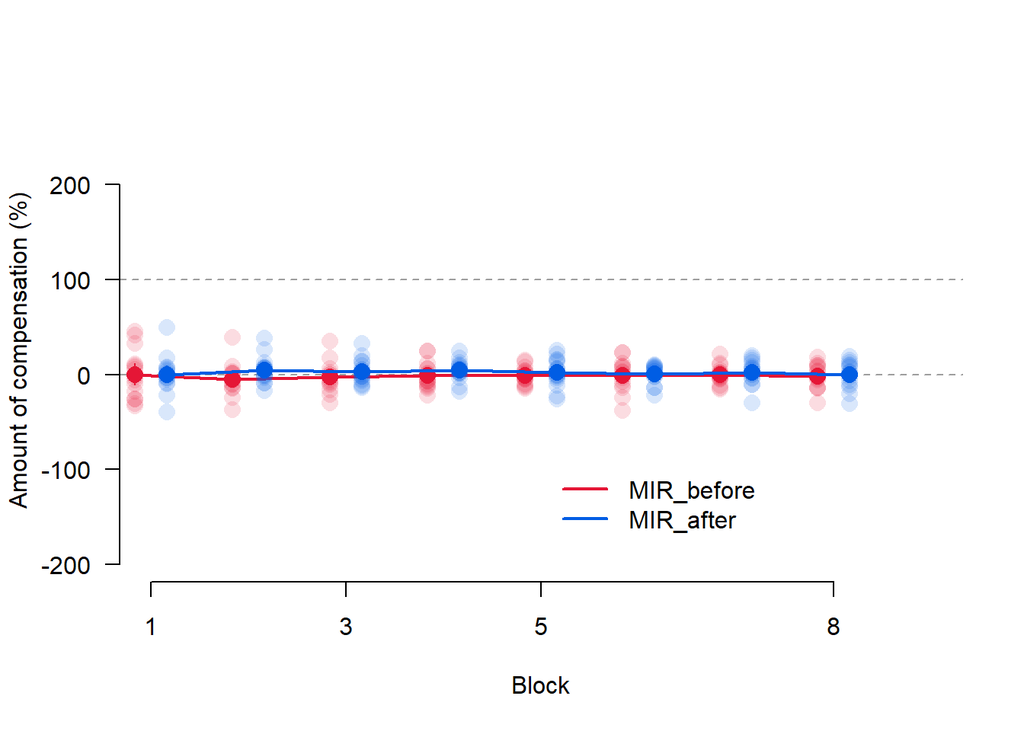

```r
plotMIRRAETargetBlocked()
```

```r
getMIRRAETargetBlockedtTests()
```

```
## Mirror before axis compared to after axis(first block):
##
##  Welch Two Sample t-test
##
## data:  MIRdat1$reachdev and MIRdat2$reachdev
## t = 0.006917, df = 28.054, p-value = 0.9945
## alternative hypothesis: true difference in means is not equal to 0
## 95 percent confidence interval:
##  -15.65816  15.76428
## sample estimates:
##  mean of x  mean of y
## -0.1226364 -0.1756942
##
## Effect Size - Cohen d:
## [1] 0.002445527
## Bayesian t-test Mirror before axis compared to after axis (first block):
## Bayes factor analysis
## --------------
## [1] Alt., r=0.707 : 0.3362102 ±0%
##
## Against denominator:
##   Null, mu1-mu2 = 0
## ---
## Bayes factor type: BFindepSample, JZS
##
## Mirror before axis compared to after axis (second block):
##
##  Welch Two Sample t-test
##
## data:  MIRdat1$reachdev and MIRdat2$reachdev
## t = -1.8343, df = 28.946, p-value = 0.07691
## alternative hypothesis: true difference in means is not equal to 0
## 95 percent confidence interval:
##  -20.293911   1.104275
## sample estimates:
## mean of x mean of y
## -5.093329  4.501489
##
## Effect Size - Cohen d:
## [1] 0.6485177
```

[output cut: 19 more lines]

```
## sample estimates:
##  mean of x  mean of y
## -1.6907567 -0.4513704
##
## Effect Size - Cohen d:
## [1] 0.09664514
## Bayesian t-test Mirror before axis compared to after axis (last block):
## Bayes factor analysis
## --------------
## [1] Alt., r=0.707 : 0.346026 ±0%
##
## Against denominator:
##   Null, mu1-mu2 = 0
## ---
## Bayes factor type: BFindepSample, JZS
```

We find no order effects, suggesting that participants had no aftereffects, regardless of target location in the mirror perturbation.

# Axis orientation effects

We check for any differences in performance, depending on whether participants experienced each perturbation in either the vertical or horizontal axis of the workspace. We compare performance both during training and during washout trials.

## Rotation Perturbation training

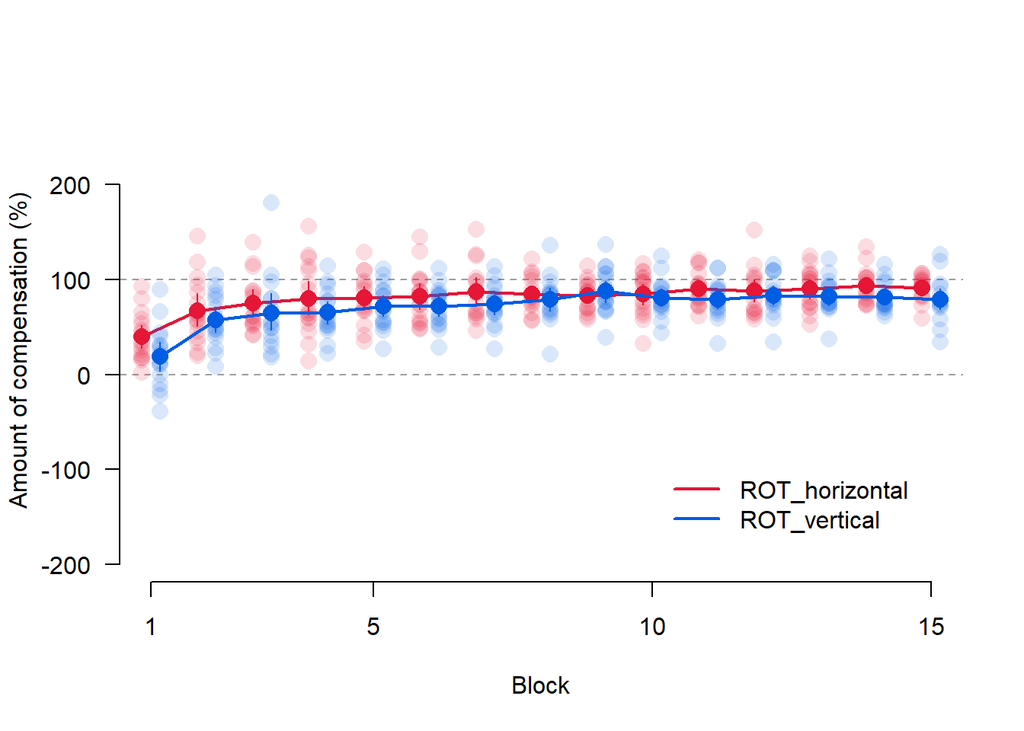

```r
plotROTAxisBlocked()
```

```r
getROTAxisBlockedtTests()
```

```
## Rotation horizontal compared to vertical axis (first block):
##
##  Welch Two Sample t-test
##
## data:  ROTdat1$reachdev and ROTdat2$reachdev
## t = 2.0348, df = 28.04, p-value = 0.05142
## alternative hypothesis: true difference in means is not equal to 0
## 95 percent confidence interval:
##  -0.1389441 42.1696706
## sample estimates:
## mean of x mean of y
##  39.52414  18.50877
##
## Effect Size - Cohen d:
## [1] 0.7194178
## Bayesian t-test Rotation horizontal compared to vertical axis (first block):
## Bayes factor analysis
## --------------
## [1] Alt., r=0.707 : 1.558429 ±0.01%
##
## Against denominator:
##   Null, mu1-mu2 = 0
## ---
## Bayes factor type: BFindepSample, JZS
##
## Rotation horizontal compared to vertical axis (second block):
##
##  Welch Two Sample t-test
##
## data:  ROTdat1$reachdev and ROTdat2$reachdev
## t = 0.88671, df = 28.268, p-value = 0.3827
## alternative hypothesis: true difference in means is not equal to 0
## 95 percent confidence interval:
##  -12.80154  32.35888
## sample estimates:
## mean of x mean of y
##  67.10822  57.32955
##
## Effect Size - Cohen d:
## [1] 0.3135004
```

[output cut: 19 more lines]

```
## sample estimates:
## mean of x mean of y
##  90.85593  78.64987
##
## Effect Size - Cohen d:
## [1] 0.6543295
## Bayesian t-test Rotation horizontal compared to vertical axis (last block):
## Bayes factor analysis
## --------------
## [1] Alt., r=0.707 : 1.206169 ±0.01%
##
## Against denominator:
##   Null, mu1-mu2 = 0
## ---
## Bayes factor type: BFindepSample, JZS
```

We find no axis orientation effects, suggesting that axis orientation has no effect on rotation perturbation learning.

## Rotation Washout trials

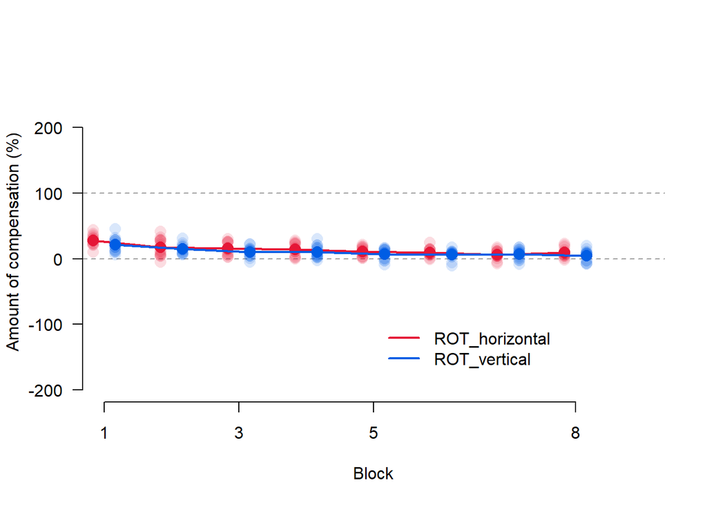

```r
plotROTRAEAxisBlocked()
```

```r
getROTRAEAxisBlockedtTests()
```

```
## Rotation horizontal compared to vertical axis (first block):
##
##  Welch Two Sample t-test
##
## data:  ROTdat1$reachdev and ROTdat2$reachdev
## t = 2.1861, df = 28.422, p-value = 0.0372
## alternative hypothesis: true difference in means is not equal to 0
## 95 percent confidence interval:
##   0.4439774 13.5123027
## sample estimates:
## mean of x mean of y
##  28.01854  21.04040
##
## Effect Size - Cohen d:
## [1] 0.7729132
## Bayesian t-test Rotation horizontal compared to vertical axis (first block):
## Bayes factor analysis
## --------------
## [1] Alt., r=0.707 : 1.953241 ±0.01%
##
## Against denominator:
##   Null, mu1-mu2 = 0
## ---
## Bayes factor type: BFindepSample, JZS
##
## Rotation horizontal compared to vertical axis(second block):
##
##  Welch Two Sample t-test
##
## data:  ROTdat1$reachdev and ROTdat2$reachdev
## t = 0.73838, df = 21.888, p-value = 0.4681
## alternative hypothesis: true difference in means is not equal to 0
## 95 percent confidence interval:
##  -4.908273 10.333237
## sample estimates:
## mean of x mean of y
##  17.35725  14.64477
##
## Effect Size - Cohen d:
## [1] 0.2610564
```

[output cut: 19 more lines]

```
## sample estimates:
## mean of x mean of y
##  8.984059  4.683545
##
## Effect Size - Cohen d:
## [1] 0.5635422
## Bayesian t-test Rotation horizontal compared to vertical axis (last block):
## Bayes factor analysis
## --------------
## [1] Alt., r=0.707 : 0.8743016 ±0%
##
## Against denominator:
##   Null, mu1-mu2 = 0
## ---
## Bayes factor type: BFindepSample, JZS
```

We find no axis orientation effects in the second and last block of washout, suggesting that axis orientation does not affect aftereffects. However, we do find a significant difference in the first block (p = .04) but the BF value of 1.95 suggests that this difference is anecdotal.

## Mirror Perturbation training

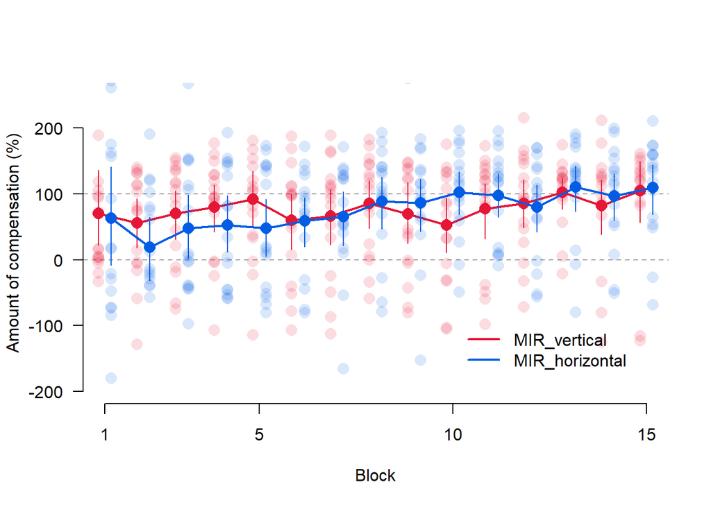

```r
plotMIRAxisBlocked()
```

```r
getMIRAxisBlockedtTests()
```

```
## Mirror horizontal compared to vertical axis (first block):
##
##  Welch Two Sample t-test
##
## data:  MIRdat1$reachdev and MIRdat2$reachdev
## t = 0.14535, df = 28.459, p-value = 0.8855
## alternative hypothesis: true difference in means is not equal to 0
## 95 percent confidence interval:
##  -93.24138 107.49593
## sample estimates:
## mean of x mean of y
##  70.14137  63.01410
##
## Effect Size - Cohen d:
## [1] 0.0513903
## Bayesian t-test Mirror horizontal compared to vertical axis (first block):
## Bayes factor analysis
## --------------
## [1] Alt., r=0.707 : 0.338954 ±0%
##
## Against denominator:
##   Null, mu1-mu2 = 0
## ---
## Bayes factor type: BFindepSample, JZS
##
## Mirror horizontal compared to vertical axis (second block):
##
##  Welch Two Sample t-test
##
## data:  MIRdat1$reachdev and MIRdat2$reachdev
## t = 1.1579, df = 28.395, p-value = 0.2565
## alternative hypothesis: true difference in means is not equal to 0
## 95 percent confidence interval:
##  -28.86657 104.04564
## sample estimates:
## mean of x mean of y
##  56.06593  18.47640
##
## Effect Size - Cohen d:
## [1] 0.4093841
```

[output cut: 19 more lines]

```
## sample estimates:
## mean of x mean of y
##  104.3909  109.2307
##
## Effect Size - Cohen d:
## [1] 0.0549286
## Bayesian t-test Mirror horizontal compared to vertical axis (last block):
## Bayes factor analysis
## --------------
## [1] Alt., r=0.707 : 0.3393475 ±0%
##
## Against denominator:
##   Null, mu1-mu2 = 0
## ---
## Bayes factor type: BFindepSample, JZS
```

We find no axis orientation effects, suggesting that axis orientation has no effect on mirror perturbation learning.

## Mirror Washout trials

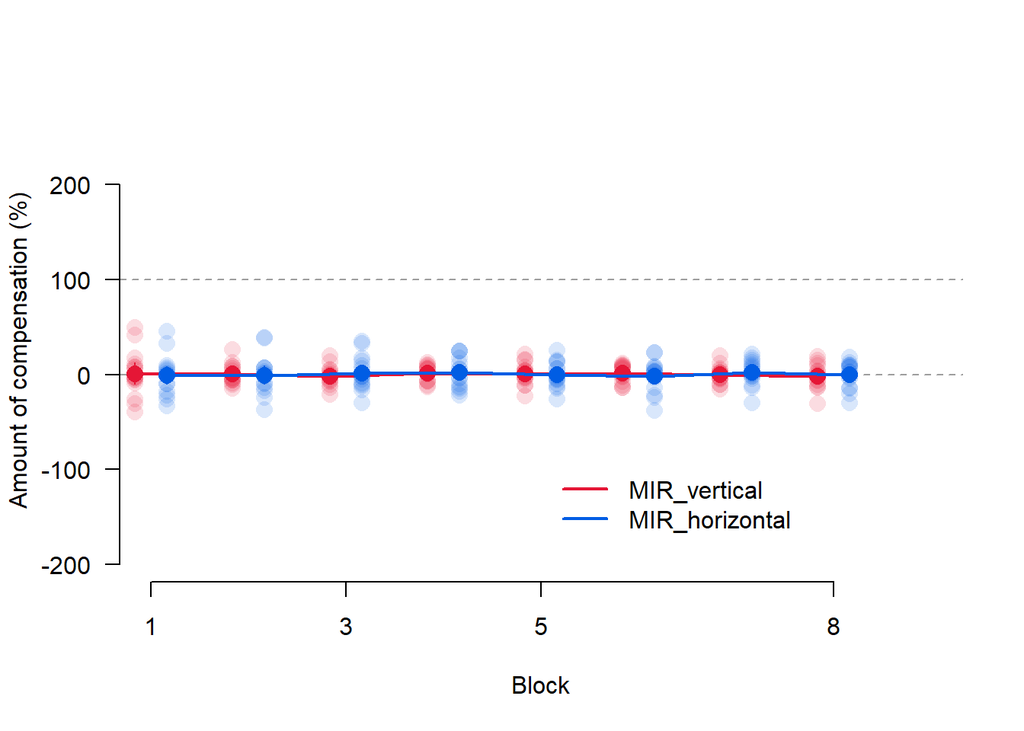

```r
plotMIRRAEAxisBlocked()
```

```r
getMIRRAEAxisBlockedtTests()
```

```
## Mirror horizontal compared to vertical axis (first block):
##
##  Welch Two Sample t-test
##
## data:  MIRdat1$reachdev and MIRdat2$reachdev
## t = 0.22904, df = 29.388, p-value = 0.8204
## alternative hypothesis: true difference in means is not equal to 0
## 95 percent confidence interval:
##  -13.91020  17.42086
## sample estimates:
##  mean of x  mean of y
##  0.7285012 -1.0268318
##
## Effect Size - Cohen d:
## [1] 0.08097714
## Bayesian t-test Mirror horizontal compared to vertical axis (first block):
## Bayes factor analysis
## --------------
## [1] Alt., r=0.707 : 0.3430714 ±0%
##
## Against denominator:
##   Null, mu1-mu2 = 0
## ---
## Bayes factor type: BFindepSample, JZS
##
## Mirror horizontal compared to vertical axis (second block):
##
##  Welch Two Sample t-test
##
## data:  MIRdat1$reachdev and MIRdat2$reachdev
## t = 0.19843, df = 22.657, p-value = 0.8445
## alternative hypothesis: true difference in means is not equal to 0
## 95 percent confidence interval:
##  -10.31963  12.50746
## sample estimates:
##  mean of x  mean of y
##  0.2510366 -0.8428771
##
## Effect Size - Cohen d:
## [1] 0.07015694
```

[output cut: 19 more lines]

```
## sample estimates:
## mean of x mean of y
## -1.689774 -0.452353
##
## Effect Size - Cohen d:
## [1] 0.09649152
## Bayesian t-test Mirror horizontal compared to vertical axis (last block):
## Bayes factor analysis
## --------------
## [1] Alt., r=0.707 : 0.3459943 ±0%
##
## Against denominator:
##   Null, mu1-mu2 = 0
## ---
## Bayes factor type: BFindepSample, JZS
```

We find no axis orientation effects, suggesting that participants had no aftereffects, regardless of the axis they trained with.